# Q4

## Question 4: What is the optimal blood pressure based on the heart failure outcomes? Does this match with the recommendations available online?

### EDA

```python
import pandas as pd
import numpy as np
import re
import seaborn as sns
import matplotlib.pyplot as plt
from statsmodels.formula.api import ols
import statsmodels.api as sm
```

```python
heart = pd.read_csv('heart.csv')
```

```python
heart.head()
```

|  | Age | Sex | ChestPainType | RestingBP | Cholesterol | FastingBS | RestingECG | MaxHR | ExerciseAngina | Oldpeak | ST_Slope | HeartDisease |
| --- | --- | --- | --- | --- | --- | --- | --- | --- | --- | --- | --- | --- |
| 0 | 40 | M | ATA | 140 | 289 | 0 | Normal | 172 | N | 0.0 | Up | 0 |
| 1 | 49 | F | NAP | 160 | 180 | 0 | Normal | 156 | N | 1.0 | Flat | 1 |
| 2 | 37 | M | ATA | 130 | 283 | 0 | ST | 98 | N | 0.0 | Up | 0 |
| 3 | 48 | F | ASY | 138 | 214 | 0 | Normal | 108 | Y | 1.5 | Flat | 1 |
| 4 | 54 | M | NAP | 150 | 195 | 0 | Normal | 122 | N | 0.0 | Up | 0 |

```python
heart.info()
```

```
<class 'pandas.core.frame.DataFrame'>
RangeIndex: 918 entries, 0 to 917
Data columns (total 12 columns):
 #   Column          Non-Null Count  Dtype
---  ------          --------------  -----
 0   Age             918 non-null    int64
 1   Sex             918 non-null    object
 2   ChestPainType   918 non-null    object
 3   RestingBP       918 non-null    int64
 4   Cholesterol     918 non-null    int64
 5   FastingBS       918 non-null    int64
 6   RestingECG      918 non-null    object
 7   MaxHR           918 non-null    int64
 8   ExerciseAngina  918 non-null    object
 9   Oldpeak         918 non-null    float64
 10  ST_Slope        918 non-null    object
 11  HeartDisease    918 non-null    int64
dtypes: float64(1), int64(6), object(5)
memory usage: 86.2+ KB
```

### Visualizations

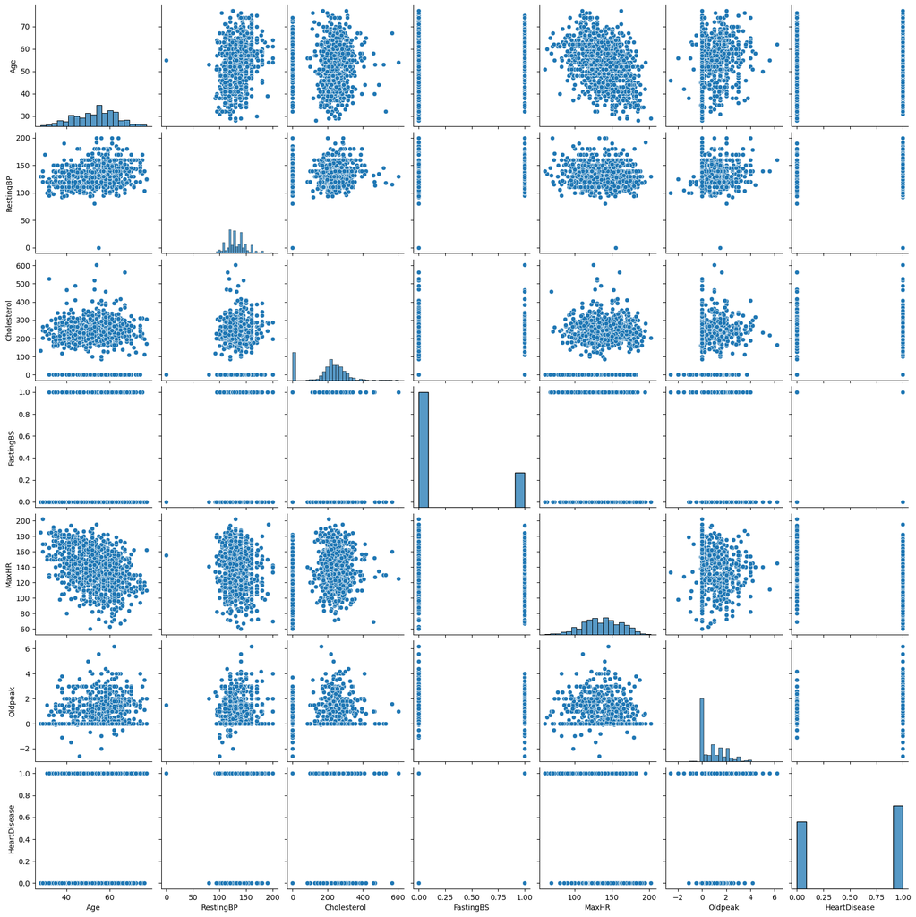

```python
sns.pairplot(heart)
```

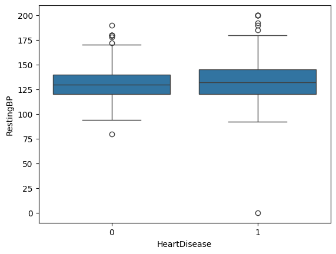

```python
sns.boxplot(x='HeartDisease', y='RestingBP', data=heart)
```

The boxplot visualizes the distribution of RestingBP for patients with and without heart disease.

Key observations:

- The median RestingBP is slightly higher for patients with heart disease compared to those without.
- There is a wider interquartile range (IQR) for patients with heart disease, indicating more variability in their RestingBP values.
- There are some outliers in both groups, but they are more pronounced in the heart disease group.

This suggests that higher RestingBP values potentially associated with a higher likelihood of heart disease.

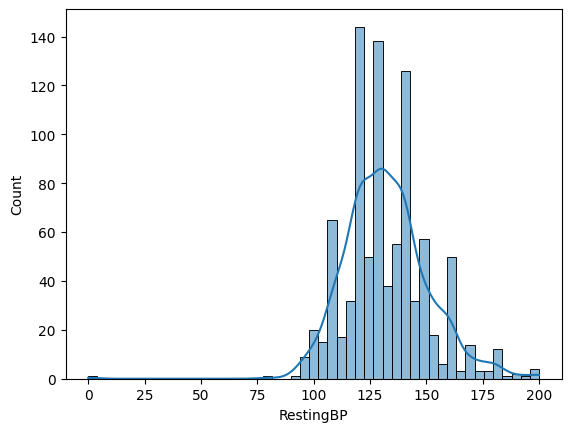

```python
sns.histplot(heart['RestingBP'],kde=True)
```

This histogram shows the distribution of Resting Blood Pressure (RestingBP) among the patients in the dataset.

Key observations:

- The distribution appears to be roughly normal, with a peak around the 120-140 range.
- There is a noticeable spread in the data, with RestingBP values ranging from below 90 to above 160.

```python
bins = [0, 90, 120, 140, 160, 200]  # Adjust bins based on the range in the dataset
labels = ['Low (<90)', 'Normal (90-120)', 'Elevated (121-140)', 'High (141-160)', 'Very High (>160)']
heart['BP_Range'] = pd.cut(heart['RestingBP'], bins=bins, labels=labels, right=False)

bp_analysis = heart.groupby('BP_Range')['HeartDisease'].agg(
    Total_Patients='count',
    HeartDisease_Positive='sum',
    HeartDisease_Negative=lambda x: x.count() - x.sum()
)

# Add a column for the proportion of HeartDisease
bp_analysis['Proportion_HeartDisease'] = bp_analysis['HeartDisease_Positive'] / bp_analysis['Total_Patients']
print(bp_analysis)
```

```
                    Total_Patients  HeartDisease_Positive  \
BP_Range
Low (<90)                        2                      1
Normal (90-120)                159                     87
Elevated (121-140)             430                    215
High (141-160)                 234                    140
Very High (>160)                89                     61

                    HeartDisease_Negative  Proportion_HeartDisease
BP_Range
Low (<90)                               1                 0.500000
Normal (90-120)                        72                 0.547170
Elevated (121-140)                    215                 0.500000
High (141-160)                         94                 0.598291
Very High (>160)                       28                 0.685393
```

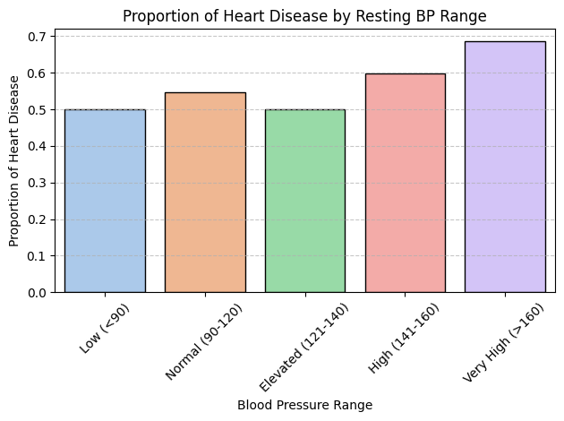

```python
sns.barplot(x=bp_analysis.index, y='Proportion_HeartDisease', data=bp_analysis, palette='pastel', edgecolor='black')
plt.title('Proportion of Heart Disease by Resting BP Range')
plt.xlabel('Blood Pressure Range')
plt.ylabel('Proportion of Heart Disease')
plt.xticks(rotation=45)
plt.grid(axis='y', linestyle='--', alpha=0.7)
plt.tight_layout()
plt.show()
```

This plot shows the proportion of patients with heart disease in each blood pressure range. We can tell that below 140 blood pressure, the proportion of people who had heart disease in the dataset is around 50%. However, for blood pressure range "141-160", the proportion of people who have heart diseases increases to 60%, and for people who have blood pressure greater than 160, their chance of having a heart disease is almost 70% percent. This indicates that having extremely high blood pressure could be associated with a higher chance of getting a heart disease.

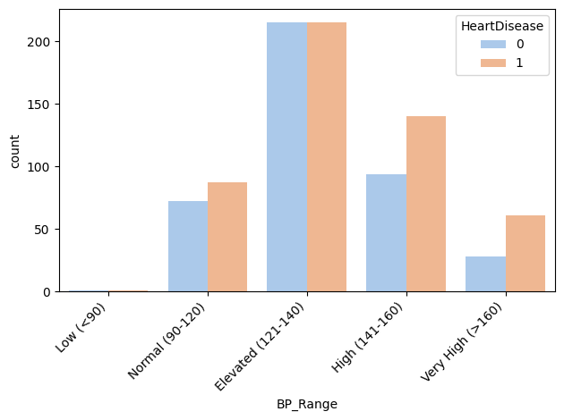

```python
sns.countplot(data=heart, x='BP_Range', hue='HeartDisease', palette='pastel')
plt.xticks(rotation=45, ha='right')
plt.tight_layout()
```

```python
# Perform ANOVA for HeartDisease
model_hd = ols('RestingBP ~ HeartDisease ', data=heart).fit()
anova_table_hd = sm.stats.anova_lm(model_hd, typ=2)
print(anova_table_hd)
```

```
                     sum_sq     df          F    PR(>F)
HeartDisease    3638.418644    1.0  10.727228  0.001095
Residual      310685.250202  916.0        NaN       NaN
```

From the ANOVA table, we can see that the p-value is smaller than 0.05, so getting this result by chance is little, showing that there is a statistically significant difference in RestingBP between the two groups: with and without heart disease.

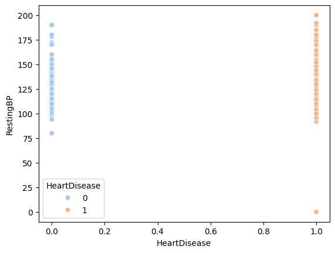

```python
sns.scatterplot(x='HeartDisease', y='RestingBP', data=heart, hue='HeartDisease', palette='pastel')
```

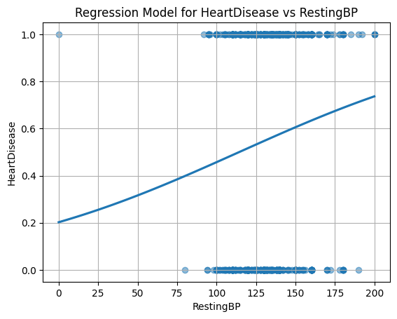

```python
sns.regplot(x='RestingBP', y='HeartDisease', data=heart, logistic=True, ci=None, scatter_kws={'alpha':0.5})
plt.xlabel('RestingBP')
plt.ylabel('HeartDisease')
plt.title('Regression Model for HeartDisease vs RestingBP')
plt.grid(True)
plt.show()
```

```python
# Calculate R-squared value
r_squared = model_hd.rsquared
print(f"R-squared: {r_squared}")
```

```
R-squared: 0.011575388697358524
```

The regplot visualizes the relationship between resting blood pressure and the likelihood of heart disease. The logistic regression line shows how the probability of heart disease changes with different values of resting blood pressure. From this plot, an upward regression line exists so I can interpret that there is a positive relationship between the heart disease incidence and the resting blood pressure. However, there is a limitation of this model. As all the data points are at the level of either 0 or 1 indicating whether that person has a heart disease, the data did not fit the model perfectly, leaving a limitation to the model for prediction. This is also shown in the r-squared value (coefficient of determination) which assesses how well the regression model explains the variability of the dependent variable. It provides an indication of the goodness of fit of the model. In this case, as the r-squared value is only 0.012, meaning that only 1.2% of the variability in HeartDisease can be explained by RestingBP. This indicates a very weak relationship between RestingBP and HeartDisease, suggesting that RestingBP alone is not a good predictor of HeartDisease in this dataset. Most of the variability in HeartDisease is likely explained by other factors not included in this model.

This workbook is wrote with the help of copilot.